# Midterm Exam: Intro to Industrial Automation & Control (100 pts)

Start Time: 1 pm ---- Submission By: 5 pm

1. PROBLEM 1: 20 pts
2. PROBLEM 2: 25 pts
3. PROBLEM 3: 20 pts
4. PROBLEM 4: 15 pts
5. PROBLEM 5: 20 pts

$\textbf{Attention:}$ Each problem has multiple parts!

# PROBLEM 1 (20 pts)

An electromechanical drive system is shown in the fugure below. A motor drives a massive element through a rack and pinion drive, producing a linear velocity. The rack and pinion drive may be considered lossless and massless, while the load mass has a value $\textbf{m}$. The DC motor produces torque $\textbf{T=Ka*i}$ ($i$ is input current to motor) and has significant armature resistance $\textbf{R}$ and inductance $\textbf{L}$. The motor is connected to a voltage source.

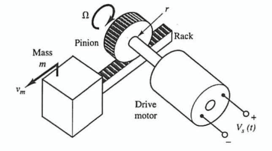

1. Create a functional block diagram of the given system with blocks for each sub-systems(translation, rotation etc.) and transducer. Note that, transducer transforms energy from one form to another. The input to the motor is $volt$ and the final output is the $velocity$ of the Mass/block. Show the flow of the physical quantities(volt, current, torque etc.) within the functional block. (5 pts)
2. The design rquirement states that, the block shall gain linear velocity of $0.5$ m/s within $2$ sec from rest position. The coefcient of friction $\mu = 0.3$ and the motor is $70$ % efficient.Create a free-body diagram and estimate the power requirment for the motor. (10 pts)
3. Perform dimensional analysis of motor torque constant $K_a$.(5 pts)

## SOLUTION

### Part 1

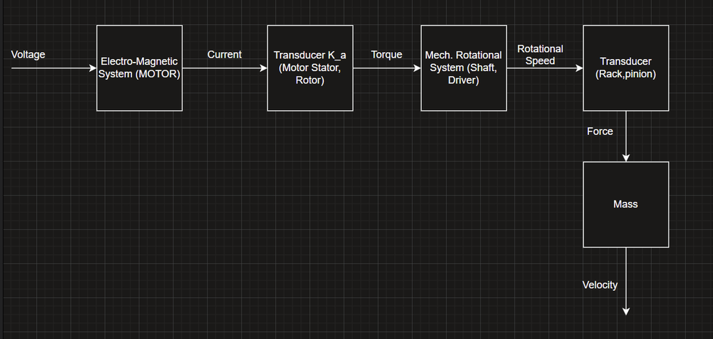

### Part 2

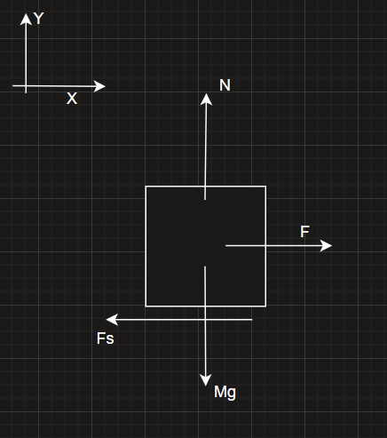

Given

$M = 30 \ kg$

$\mu_s = 0.3$

$v_x = 0.5 \ m/s$

$t = 2 \ s$

$\eta = .70$

Assumptions

$\Rightarrow$Initially the block has $0$ velocity

$\Rightarrow$considering only static friction

$\Rightarrow$When the block starts moving, we shall ignore kinatic friction.

Applay governing equation

$\sum F_x = M \cdot a_x = M \cdot \frac{v_x}{t}$

$\Rightarrow F-F_s = M \cdot \frac{v_x}{t} $

$\Rightarrow F-N*\mu_s = M \cdot \frac{v_x}{t} $

$\Rightarrow F-Mg*\mu_s = M \cdot \frac{v_x}{t} $

F = 95.79 N

Instant Power Requirement to move the block and acheive 0.5 m/s

$P = F*v = 47.9$ watt

Motor power requirement

$P_{in} = \frac{P_{out}}{0.7} = 68.43$ watt

### Part 3

$K_a = \frac{T}{i} = \frac{N*m}{Amp}= \frac{kg*m^2}{s^2*Amp} = [M L^2 T^{-2} I^{-1}]$

# PROBLEM 2 (25 pts)

A simple belt-drive system shall be used to vertically lift mass $M$ at $V_m$ velocity. The radius of the bigger sheave is $R$, driven by the driver sheave through a DC motor.

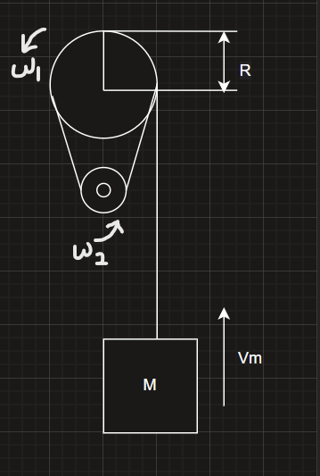

Feel free to use MATLAB documentation on function handling [ https://www.mathworks.com/help/matlab/function-handles.html ]

## SOLUTION

### Part 1

Given

$R=20 \ cm$

$\omega_2/\omega_1 = SR = 2.5$

Assumption

$\Rightarrow$ Considering steady state when block is moving vertically in $V_m$

$\omega_1 = \frac{V_m}{R}*\frac{30}{\pi} \approx = 14.5 \ RPM$

$\omega_2 = SR*14.5 \ RPM = 36.25 \ RPM$

### Part 2

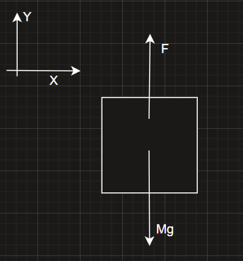

Assumption

$\Rightarrow$ Considering the block initially at rest

$\Rightarrow$ Considering the block reaches $V_m$ within 2 sec

$\Rightarrow$ Considering no loss due to rotational friction

$F = mg+m*(\frac{V_m}{t}) \approx 300N$

$P = 300*0.3048 \approx 91.5$ watt

$P_{in} = \frac{P_{out}}{.80} \approx 114.3$ watt

Therefore, $100$ watt motor will not meet the design requirment!

### Part 3

$\omega_1(t) = \frac{1}{R} * V_m(t) * \frac{30}{\pi}$

$\omega_2(t) = SR*\omega_1(t)$

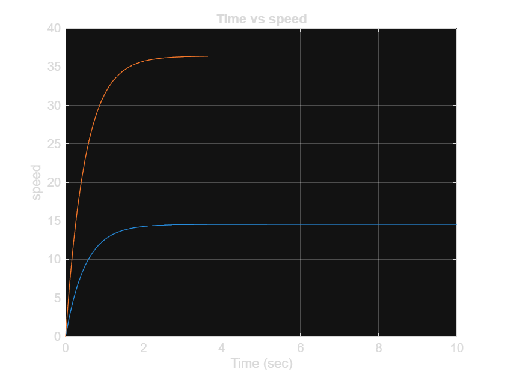

```matlab
R = .2; % radius of bigger sheave
SR=2.5; % speed ratio

% define the function
w1=@(t) (30/3.1416).*(.3048.*(1-exp(-2*t)))/R ;

w2=@(t) SR.*(30/3.1416).*(.3048.*(1-exp(-2*t)))/R ;

% define time vector
t = linspace(0,10);

figure
plot(t,w1(t)) % time vs speed w1 plot
hold on
grid on
plot(t,w2(t)) % time vs speed w2 plot
xlabel('Time (sec)');
ylabel('speed');
title('Time vs speed');
```

The plot suggests that it takes apporx 2 sec to reach steady state as $\omega_1$ and $\omega_2$ reaches to their required speed.

# PROBLEM 3 (20 pts)

Natural response of a simple mass-spring system can be expressed with

$$x(t)=A \cdot sin(\omega \cdot t)----(1)$$

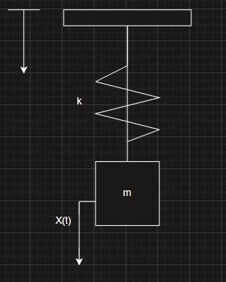

1. Create a free body diagram and varify that the differential equation for this system is (5pts) $$ m\ddot{x(t)}+kx(t) = 0----(2)$$ (hint: no damper so $C=0$)
2. Determine the value of $\omega$ (natural frequency) in eq.1 such that eq.1 satisfys eq.2. (hint: $\omega$ should have expression interms of k and m) (5 pts)
3. For initial condition $x(0)=0$ and $\dot{x(0)}=V_{max},$determine the value of A. (apply these conditions to eq.1) (5 pts)
4. Modify the code below for w, A, f1 (position function) and f2 (velocity function) and generate plot. parameter values for $m = 2 \ kg$, $V_{max} = 1 \ m/s$ and $k = 4 \ n/m$ are provided.(5 pts)

Feel free to use MATLAB documentation on function handling [ https://www.mathworks.com/help/matlab/function-handles.html ]

## SOLUTION

### Part 1

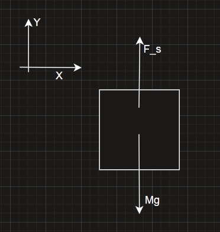

$\sum F_y = ma_y$

$F_s - Mg = -ma_y$

note that, we have considered $+y$ as positive direction. From hook's law we can state that,if spring is pulling upward, block would be moving downward. therefore, $-ma_y$

The correct differential equation for this system would be

$m\ddot{x(t)}+kx(t) = Mg$

### Part 2

To find natural frequency, we have to use Eq. (2) (homogenous equation)

$\ddot{x(t)} = -A*\omega^2*sin(\omega*t)$

Therefore,

$m\ddot{x(t)}+kx(t) = 0 = m*-A*\omega^2*sin(\omega*t) + k*A*sin(\omega*t)$

$\omega = \sqrt{\frac{k}{m}}$

### Part 3

$\dot{x(0)} = A*\omega*cos(0) $

$\Rightarrow A = \frac{V_{max}}{\omega}$

### Part 4

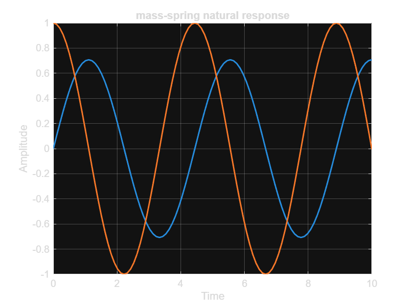

```matlab
m=2; % mass
k=4; % stiffness
vm =1; % max velocity

%******************************************YOUR CODE*******************************
w = sqrt(k/m); % from part 2
A = vm/w; % from part 3
f1 = @(t) A*sin(w.*t); %function definition
f2 = @(t) A*w*cos(w.*t); %function definition
%**********************************************************************************


t = linspace(0,10,100); % time vector from 0 sec to 10 sec with 100 points
figure
plot(t,f1(t),'LineWidth', 1.5)
xlabel('Time')
ylabel('Amplitude')
grid on
hold on
plot(t,f2(t),'LineWidth', 1.5)
title('mass-spring natural response')
```

# PROBLEM 4 (15 pts)

For the given system below, do the following:

1. Simplify by finding equivalent spring. (3 pts)
2. Draw free body diagram for each block and write respective governing equation for each block. (10 pts)
3. In Problem 3, Part 2, you determined the natural frequency of the system. Do you think the natural frequency of each individual block (if disconnected from the other) would be the same as when the blocks are connected together? Explain your reasoning. How can you determine this by inspecting the governing equations? (2 pts)

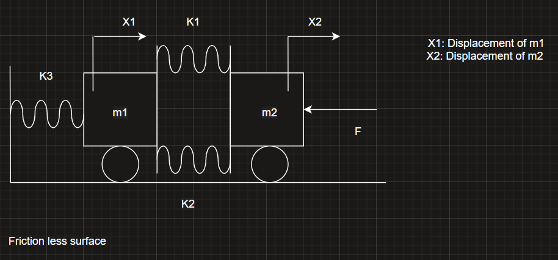

## SOLUTION

### Part 1

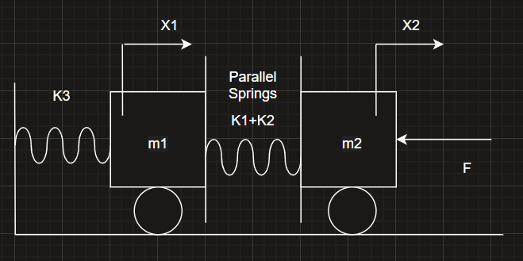

### Part 2

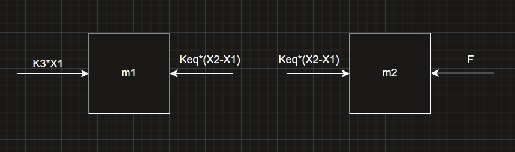

Equation for block 2

$m_2\ddot{X_2(t)} = F-K_{eq}*(X_2(t)-X_1(t))$

Equation for block 1

$m_1\ddot{X_1(t)} = K_{eq}*(X_2 - X_1) - (K3*X_1) $

### Part 3

Assuming,

We can attache mass m1 and m2 individually with spring K3 to find their individual natural frequency.

By inspection, the diff.eq of conencted blocks shows that,

$\omega_1 \neq \sqrt{\frac{k_3}{m_1}}$

$\omega_2 \neq \sqrt{\frac{k_3}{m_2}}$

# PROBLEM 5 (20 pts)

1. For the circuit below find $V_3$ in terms of input voltage $V_s$ and Resistors(5 pts)

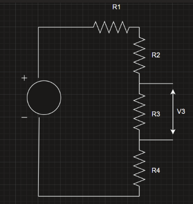

2. For the series CL circuit below, write Kirchoff Voltage Law and Kirchoff Current Law. (KCL hint: find incoming and outgoing current at node A and then B.) (5 pts)

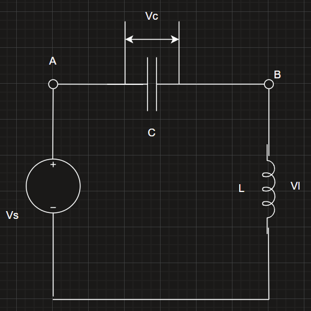

3. From part 2, the equations for capacitor current $i_c(t)$ and voltage $v_c(t)$ can be written as $$ \frac{di_c}{dt} = \frac{-1}{L}v_c(t)+ \frac{1}{L}v_s $$ $$ \frac{dv_c}{dt} = \frac{1}{C}i_c(t) $$

If state vector $$\vec{\mathbf{X}}= \begin{bmatrix} x_1 \\ x_2 \end{bmatrix} $$

$x_1:$ $i_c$ and $x_2:$ $v_c$

input vector

$$\vec{\mathbf{U}}= \begin{bmatrix} u_1 \\ u_2 \end{bmatrix} $$

$u_1:$ $v_s$ ;

$u_2:$ 0

Find system matrix $[A]$ and input matrix $[B]$. Substitute your values for these matrices into matlab code below and simulate impulse response. (10 pts)

Feel free to use MATLAB state space documentation [ https://www.mathworks.com/help/control/ref/ss.html ]

## SOLUTION

### Part 1

$V_3 = V_S(\frac{R_3}{R_1+R_2+R_3+R_4})$

### Part 2

KVL

$\sum_{loop} Voltage = 0$

$V_s - V_c(t)-V_l(t)=0$

KCL

$\sum_{node} Current = 0$

$I_{total} = i_c = i_l$

### Part 3

```
ans = 1×3 double
   200     2     2
```

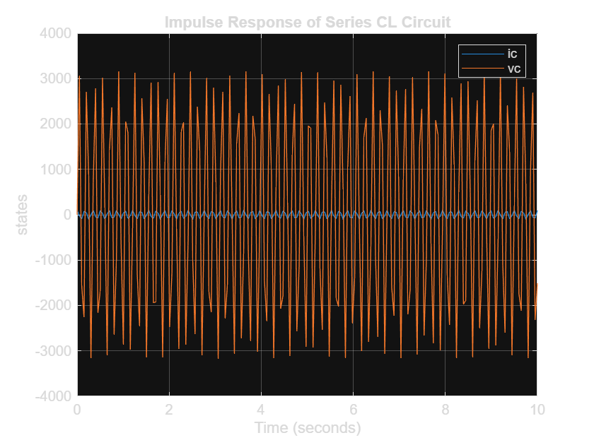

```matlab
%param
L = .01;
C = .00001;
A = [0,-1/L;1/C,0]; % Modify A matrix (your A matrix)
B = [1/L, 0;0,0]; % modify B matrix (your B matrix)
C = [1,0 ; 0 , 1];
D = 0;
sys = ss(A,B,C,D,'StateName',{'ic' 'vc'},...
'InputName','volt');
% Plot the impulse response
t = linspace(0,10,200);
y = impulse(sys,t);
size(y)
figure;
plot(t,y(:,1));
grid on
hold on
plot(t,y(:,2))
title('Impulse Response of Series CL Circuit');
ylabel('states');
xlabel('Time (seconds)');
legend('ic','vc')
grid on;
```